# ETC5521: Diving Deeply into Data Exploration

## Including uncertainty in plots

## The usual approach: Error bars bolted on

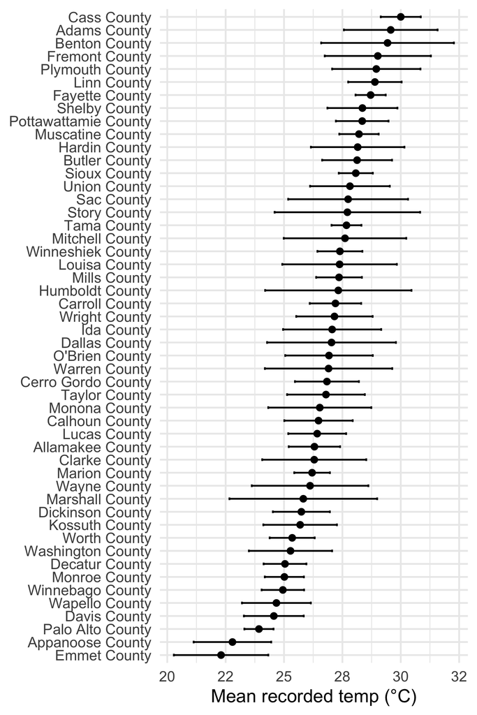

```r
set.seed(1134)
county_name_sample <-
  toy_temp |>
  select(county_name) |>
  distinct() |>
  sample_frac(0.5) |>
  pull(county_name)

toy_temp_eg <- toy_temp |>
  filter(county_name %in% county_name_sample) |>
  group_by(county_name) |>
  summarise(
    mean_temp = mean(recorded_temp),
    se_temp   = sd(recorded_temp) / sqrt(n())
  )

ggplot(toy_temp_eg, aes(x = fct_reorder(county_name, mean_temp), y = mean_temp)) +
  geom_point() +
  geom_errorbar(aes(ymin = mean_temp - 2*se_temp,
                     ymax = mean_temp + 2*se_temp), width = 0.2) +
  labs(y = "Mean recorded temp (°C)", x = NULL) +
  coord_flip() +
  theme_minimal()
```

Uncertainty is a *separate layer* added after the fact — easy to skip, easy to ignore.

## ggdibbler: Uncertainty *is* the data

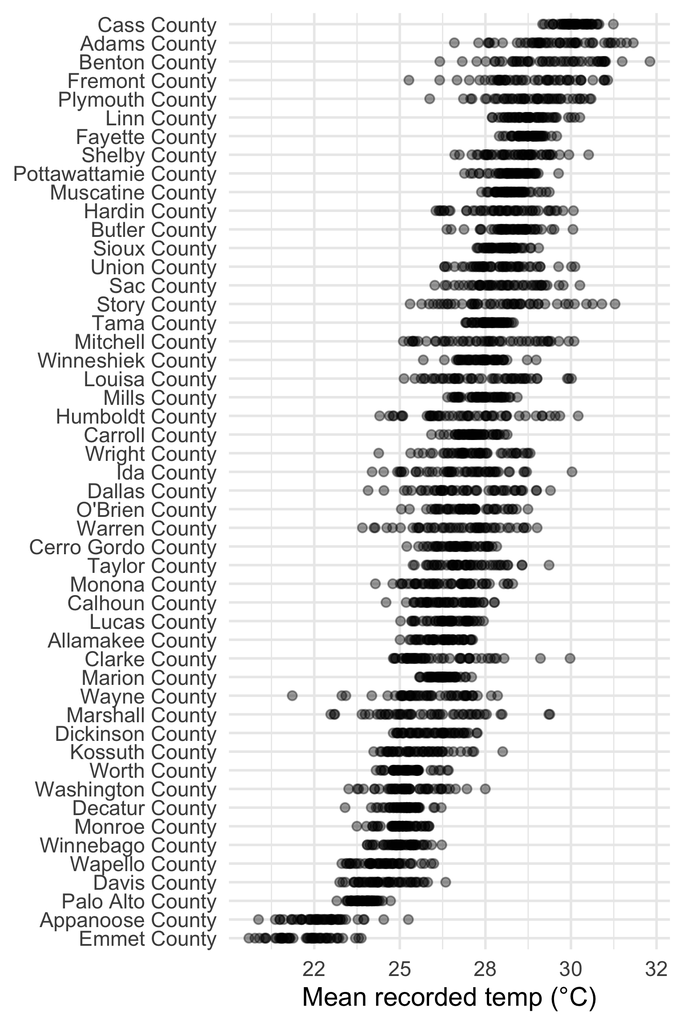

```r
library(ggdibbler)
library(distributional)

# Same summary, but the estimate becomes a DISTRIBUTION, not a number
toy_temp_dist <- toy_temp |>
  filter(county_name %in% county_name_sample) |>
  group_by(county_name) |>
  summarise(
    temp_dist =
      dist_normal(mu = mean(recorded_temp),
                             sigma = sd(recorded_temp) / sqrt(n()))
  ) |>
  mutate(county_name = fct_reorder(county_name, temp_dist, .fun = mean))

ggplot(toy_temp_dist,
    aes(x = county_name,
    y = temp_dist)) +
  geom_point_sample(times = 50, alpha = 0.4) +
  labs(y = "Mean recorded temp (°C)", x = NULL) +
  coord_flip() +
  theme_minimal()
```

Swap the number for a `dist_normal()`, use the `_sample` geom, and ggdibbler draws `times` plausible realisations — uncertainty shows up as visual spread/noise, the same plot you’d already make, just fed a random variable instead of a point estimate.

## The problem of making thousands of comparisons

## Case study: gene expression (1/2)

A typical experiment tests **every gene** for a difference between conditions: often 20,000+ tests at once, each with its own $p$-value.

- At $\alpha = 0.05$, **5% of truly null genes will look “significant” by chance alone**
- With 20,000 genes and (say) 18,000 truly unaffected by the treatment:

$18{,}000 \times 0.05 \approx 900$ false positives, even if nothing real is happening

- A single-test error rate ($\alpha$) controls the wrong thing here: it bounds the false-positive rate *per test*, not across the whole gene list you’ll actually report

The fix: control the **False Discovery Rate**, not $\alpha$ used in each test

**Benjamini–Hochberg** procedure: rank $p$-values, adjust each against its rank, relative to number of tests, keep everything below the corresponding threshold.

## Case study: gene expression (1/2)

Gene expression studies rarely have more than a handful of replicates per group (often $n = 3$–$5$). A t-statistic depends on the **variance estimate**:

$$t = \frac{\bar{x}_1 - \bar{x}_2}{s_{\text{pooled}} \sqrt{2/n}}$$

- By chance, some genes get an *artificially small* $s^2$ → an inflated $t$ → a “highly significant” result that’s really just an unlucky variance estimate, not a real effect
- This is the same fragility problem as small-sample A/B tests — but multiplied across thousands of genes simultaneously

(Also can think of this as some genes have more impact than others with smaller expression.)

The fix: **Empirical Bayes shrinkage** of variance estimates, or **moderated t-statistic**

- Each gene has too little data on its own, but *thousands of other genes* are measured in the same experiment
- Borrow strength across genes: shrink each gene’s variance estimate toward the **typical variance seen across all genes**, weighted by how reliable that gene’s own estimate is.

The common thread: both are about *not letting one noisy comparison speak for itself* — FDR corrects for volume of tests, empirical Bayes corrects for scarcity of data per test.

## Generating comparison samples

## Bootstrap confidence intervals

For choropleth vs hexagon tiles, sample participants with replacement.

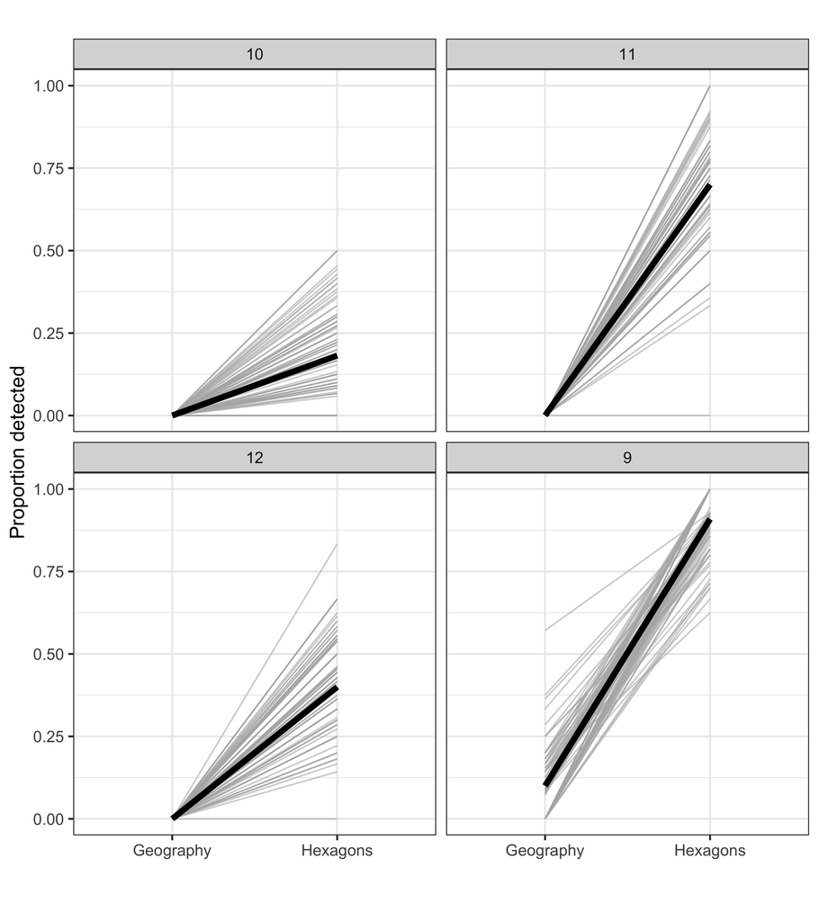

```r
hstudy |> filter(trend == "three cities") |> count(type, replicate)
```

```
# A tibble: 8 × 3
  type      replicate     n
  <chr>         <dbl> <int>
1 Geography         9    10
2 Geography        10    10
3 Geography        11    11
4 Geography        12    11
5 Hexagons          9    11
6 Hexagons         10    11
7 Hexagons         11    10
8 Hexagons         12    10
```

```r
hstudy_sub <- hstudy |>
  filter(trend == "three cities") |>
  select(id, type, replicate, detect)

# Function to compute proportions
prop_func <- function(df) {
  df_smry <- df |>
    group_by(type, replicate) |>
    summarise(pdetect = length(detect[detect == 1])/length(detect)) |>
    ungroup() |>
    pivot_wider(names_from = c(type, replicate),
               values_from = pdetect)
  df_smry
}

nboots <- 100
set.seed(1023)
bsamps <- tibble(samp="0", prop_func(hstudy_sub))
for (i in 1:nboots) {
  samp_id <- sort(sample(unique(hstudy_sub$id),
    replace=TRUE))
  hs_b <- NULL
  for (j in samp_id) {
    x <- hstudy_sub |>
      filter(id == j)
    hs_b <- bind_rows(hs_b, x)
  }
  bsamps <- bind_rows(bsamps,
    tibble(samp=as.character(i), prop_func(hs_b)))
}

bsamps_long <- bsamps |>
  pivot_longer(Geography_9:Hexagons_12,
    names_to = "treatments",
    values_to = "pdetect") |>
  separate(treatments, into=c("type", "replicate"))

ggplot() +
    geom_line(data=filter(bsamps_long, samp != "0"),
      aes(x=type,
          y=pdetect,
          group=samp),
     linewidth=0.5, alpha=0.6, colour="grey70") +
    geom_line(data=filter(bsamps_long,
                     samp == "0"),
      aes(x=type,
          y=pdetect,
          group=samp),
     linewidth=2) +
    facet_wrap(~replicate) +
    ylim(c(0,1)) +
    xlab("") +
    ylab("Proportion detected")
```

## Lineups

- Lineups show what might happen to estimates with null samples, where (by construction) there is no relationship.
- Thus you need to break dependence structure.

For choropleth vs hexagon tiles, randomise the type of plot each participant received. This breaks any dependence between type and detection rate.

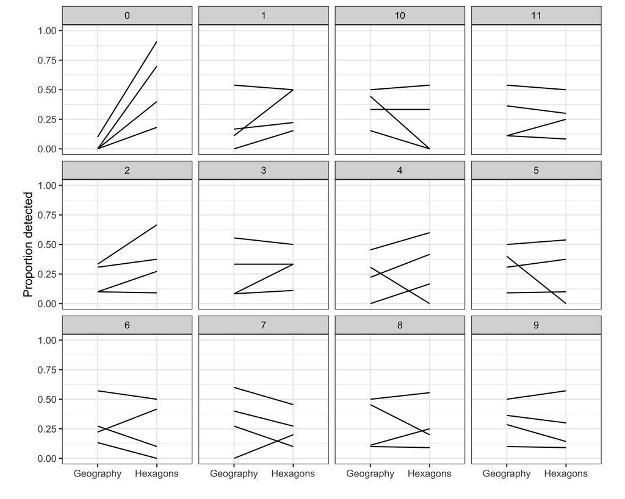

```r
n_nulls <- 11
set.seed(1110)
lsamps <- tibble(samp="0", prop_func(hstudy_sub))
for (i in 1:n_nulls) {

  hs_b <- hstudy_sub |>
    group_by(id) |>
    mutate(type = sample(type)) |>
    ungroup()
  lsamps <- bind_rows(lsamps,
    tibble(samp=as.character(i), prop_func(hs_b)))
}

lsamps_long <- lsamps |>
  pivot_longer(Geography_9:Hexagons_12,
    names_to = "treatments",
    values_to = "pdetect") |>
  separate(treatments, into=c("type", "replicate"))

lsamps_long |> ggplot() +
    geom_line(aes(x=type,
          y=pdetect,
          group=replicate)) +
    facet_wrap(~samp, ncol=4) +
    ylim(c(0,1)) +
    xlab("") +
    ylab("Proportion detected")
```

## Activity: Comparisons gone wrong, for real

On December 5, 2025, the University of Nebraska Board of Regents voted 7-1 to eliminate the Department of Statistics at UNL entirely, along with three other departments (Earth and Atmospheric Sciences, Educational Administration, and Textiles, Merchandising and Fashion Design), as part of a $6.74 million cut affecting 51.5 positions — Statistics alone accounted for $1.75 million and 12 eliminated positions. All degree programs (BS, MS, PhD) were closed, and tenured and tenure-track faculty were let go, with their last day of employment set for May 14, 2027.

The decision leaned heavily on a set of cross-department performance metrics — exactly the kind of *comparison* problems from today’s lecture.

**Your turn**

Look at the 7 slides under “Comparisons” in the [UNL Statistics faculty’s rebuttal deck](https://unl-statistics.github.io/2025-metrics-seminar/#/comparisons).

Can you see what comparison calculation was wrong?

- Bundling every department’s SRI into one distribution ignores that fields differ enormously in citation norms, grant sizes, and publishing rates — comparable to the “fruit salad” mixture-distribution problem: a mixture is fine for describing the whole university, but not for ranking individual departments against each other.
- A department’s position in a “shift” plot depends on which comparison group and time window it’s judged against; without a consistent, disclosed baseline for every department, claims of “equal treatment” can’t be verified — this is the same transparency issue as the OvaCheck calibration failure.
- Taking a difference relative to a reference group (e.g. public AAU institutions) is exactly the *baseline comparison* idea from today: it controls for field-wide norms so the number reflects relative standing, not just which discipline you’re in.
- Ranking departments on raw, un-standardised metrics compares apples to pumpkins — the fix is the same one we used all lecture: identify the correct strata, standardise within them, and always ask “compared to what?” before trusting a ranking.

## Key points

- *Compared to what* is especially important for exploring observational data — the strata, dependencies, and baseline all need to be identified before comparing.
- Adjust for individual variation, by
  - pairing (or repeated measures on the same unit)
  - comparing relative to a baseline
  - standardising onto a common scale (z-score, rate, index, …)
- Calibration matters: comparisons across batches, instruments, or samples can produce spurious “signals” if not properly randomised or normalised — it’s the process being compared, not the effect of interest.
- When data only records presence (not absence), join against the complete set of possibilities so missing combinations count as zero, not nothing.
- Uncertainty should be part of the estimate, not an afterthought bolted on with error bars.
- Making many comparisons at once inflates the chance of false discoveries — correct for multiplicity.
- Bootstrap samples and permutation lineups let you simulate what the comparison would look like under resampling or under no real effect, to judge whether an observed difference is real.

## Resources

- Wilke (2019) [Fundamentals of Data Visualization](https://clauswilke.com/dataviz/) Chapters 9, 10, 11
- Unwin (2015) [Graphical Data Analysis with R](http://www.gradaanwr.net) Chapter 10
- UNL Statistics faculty (2025) [The Metrics: The Good, the Bad, and the Ugly](https://unl-statistics.github.io/2025-metrics-seminar/) — rebuttal seminar on the metrics used to justify the elimination of the UNL Department of Statistics